# Biogeochemical Cycling

## Matter is conserved — but ecosystems are open

- **Law of Conservation of Mass: Matter cannot be created or destroyed**
  - elements move among locations and change chemical form
- **At the global scale, matter is conserved**
  - C, N, P and other elements remain part of the Earth system
- **Individual ecosystems can gain or lose matter**
  - mineral nutrients enter and leave through water, air, organisms and disturbance

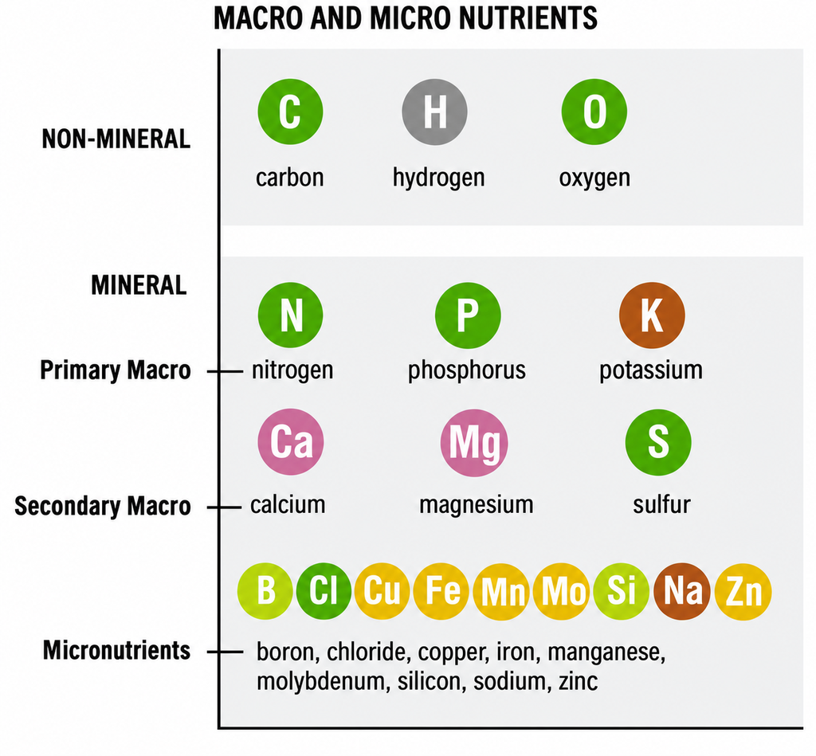

## Energy flows, but matter cycles

- **Energy moves directionally**
  - enters ecosystems largely as sunlight
  - ultimately leaves as heat
- **Matter is reused**
  - atoms move repeatedly between organisms and the physical environment
- Two major ecosystem processes:
  - **energy flow**
  - **matter cycling**

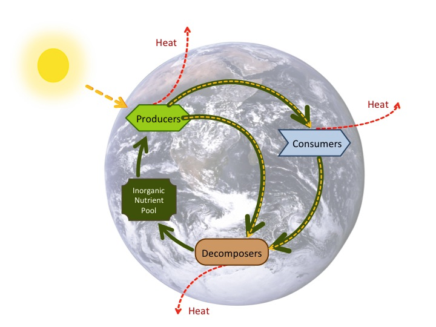

[figure not shown]

## How ecologists describe a biogeochemical cycle

- **Pool / stock = amount of an element stored in a location**
- **Flux = rate of movement between pools**
- **Transformation = change from one chemical form to another**
- **Residence time = how long matter tends to remain in a pool**
- **1. How much is there? 2. How fast is it moving? 3. What form is it in? 4. How long does it stay?**
  - Large pool ≠ large flux

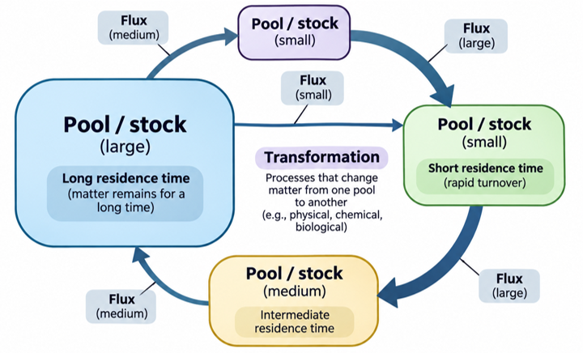

## Biological availability depends on chemical form

- **Abundance does not equal availability**
- **Nitrogen is abundant in the atmosphere**
  - most organisms cannot use N<sub>2</sub> directly
  - plants primarily acquire NH<sub>4</sub><sup>+</sup> and NO<sub>3</sub><sup>-</sup>
- **Elements can move between:**
  - inorganic forms
  - organic molecules
  - unavailable or slowly available pools
- **Transformations determine who can use an element**

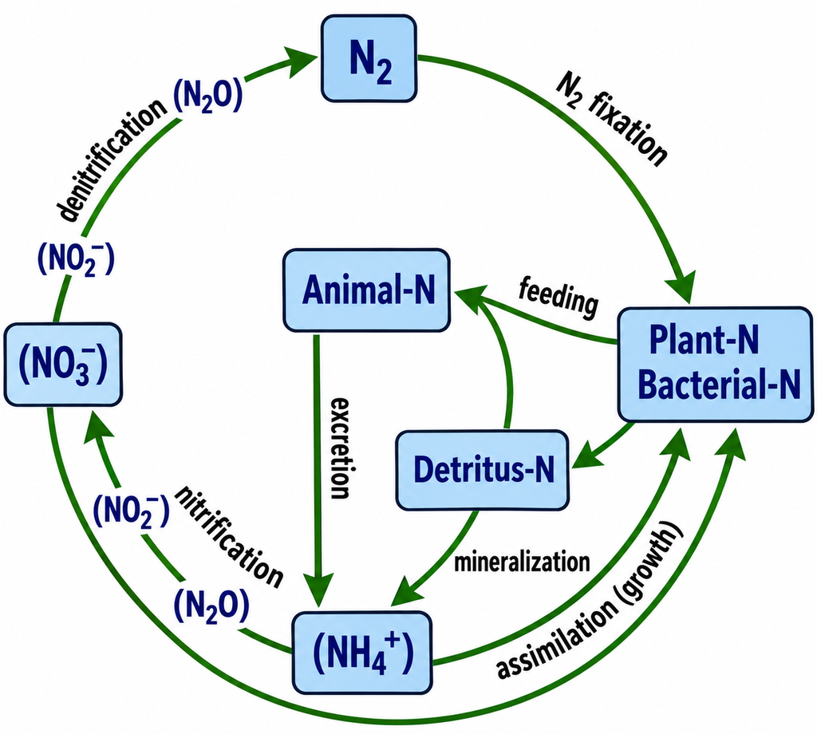

## Nutrient limitation constrains ecosystem productivity

- **Limiting nutrient = resource whose availability constrains biological production**
  - photosynthetic *producers* operate under nutrient limitation
- **Limitation varies among ecosystems**
  - N limitation
  - P limitation
  - **co-limitation**
- **How do we test nutrient limitation?- manipulate nutrient supply:**
  - control, +N, +P, +N and +P
  - compare the biological response among treatments

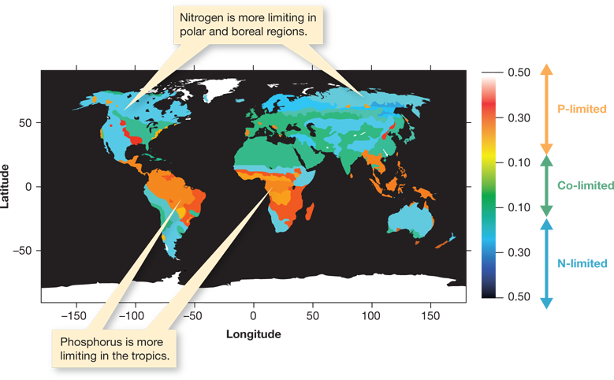

## Ecological stoichiometry: organisms need elements in ratios

- **Organisms do not need unlimited amounts of a single nutrient**
  - they require *C, N, P and other elements in particular proportions*
- **Elemental balance can influence:**
  - plant growth
  - food quality
  - decomposition
  - nutrient recycling
- **A surplus of one element cannot always compensate for shortage of another**
- **Growth depends on the balance among elements, not just the absolute amount of one nutrient**

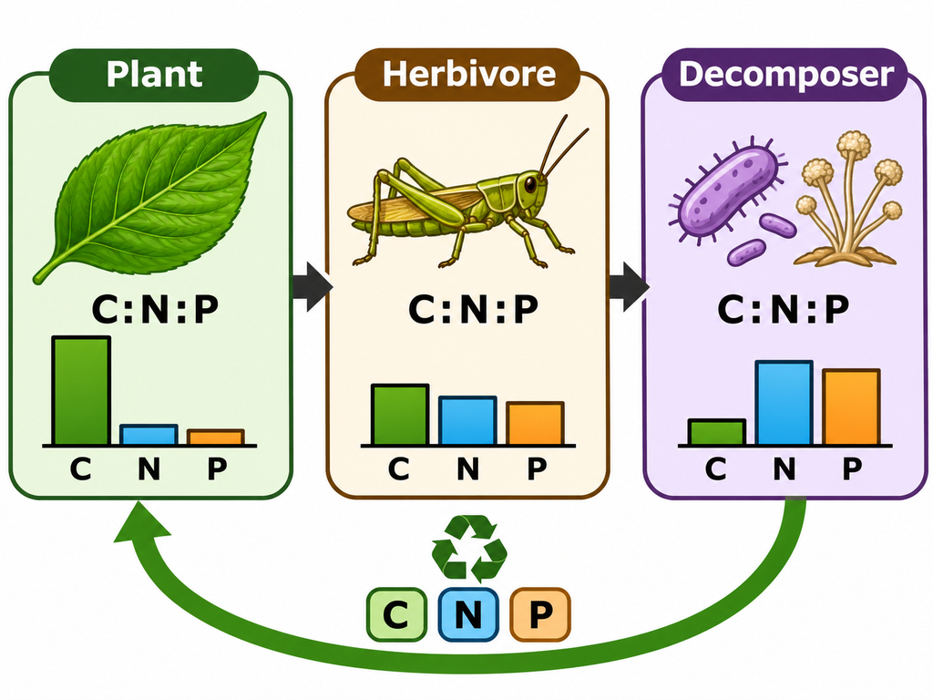

## Biogeochemical cycles operate across global reservoirs

- **Atmosphere • Hydrosphere • Lithosphere • Biosphere • Cryosphere**
- **Reservoirs differ in:**
  - amount stored
  - chemical form
  - residence time
  - rates of exchange with other reservoirs

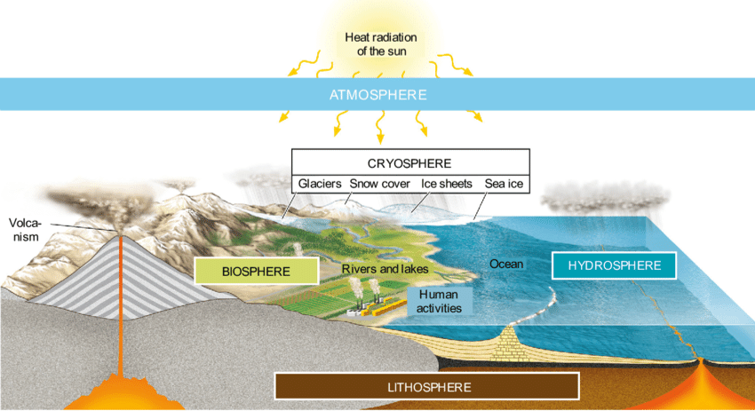

## Ecosystem cycles: Nutrient budgets

- **Inputs**
  - fixation
  - weathering
  - atmospheric deposition
- **Internal recycling**
  - food webs
  - decomposition
  - biological uptake
- **Outputs**
  - gaseous losses
  - leaching / runoff
  - erosion and disturbance

**Change in storage = inputs − outputs**

- Disturbance can increase nutrient loss
  - recovery can increase nutrient retention

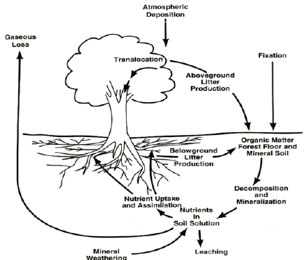

## Carbon cycle: Ecosystem pools and fluxes

- **Photosynthesis transfers atmospheric or aquatic CO<sub>2</sub> into organic carbon**
- **Respiration and decomposition return carbon to inorganic forms**
- **Carbon can be stored for very different lengths of time in biomass, soils, oceans and sediments**
- **How much is there? How fast is it moving? What form is it in? How long does it stay?**

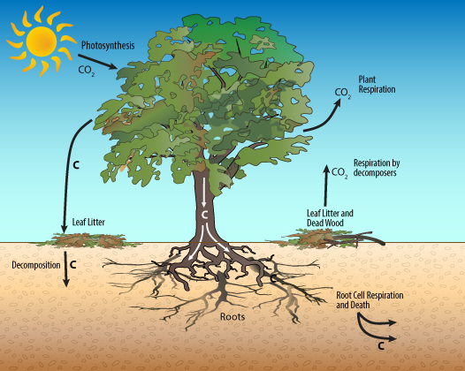

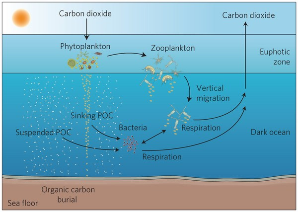

## Carbon storage and movement

- **Reservoir / pool = stores carbon**
- **Source = releases more carbon than it absorbs**
- **Sink = absorbs more carbon than it releases**
- **These terms are not interchangeable**
  - a large reservoir is not necessarily a strong sink
- **A system can shift between source and sink through time**
  - especially with human activities

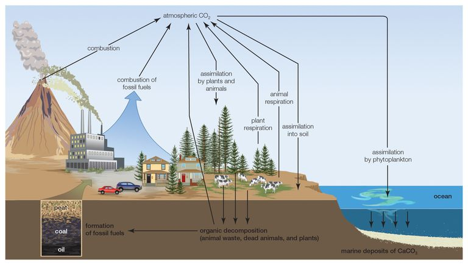

## Humans have greatly altered the global carbon budget

- **Fossil fuels and land-use change move carbon into the atmosphere**
- **2015–2024 average:**
  - Ocean sink ≈ 29%
  - Land sink ≈ 21%
  - ~50% remains in the atmosphere

[figure not shown]

## Carbon sinks are dynamic — not limitless

- **Sink strength changes through time**
  - climate variability
  - drought and fire
  - warming
  - land-use change
- **Storage and sink strength are different**
  - a reservoir may contain enormous amounts of carbon without currently gaining carbon rapidly
- **Ocean acidification occurs partly because oceans are absorbing CO<sub>2</sub>**
  - it does not mean oceans have stopped storing carbon

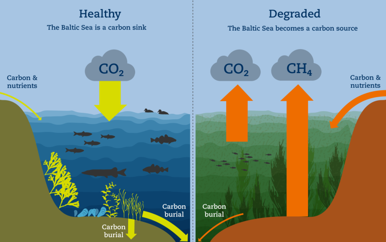

## Nitrogen: abundant but often unavailable

- **~78% of the atmosphere is N<sub>2</sub>**
- **Most organisms cannot directly use atmospheric N<sub>2</sub>**
  - however, nitrogen demand is high
- **Microorganisms control many key transformations**
  - generate biologically available forms
  - recycle nitrogen
  - return nitrogen to the atmosphere
- **Nitrogen cycling therefore depends strongly on microbial metabolism**

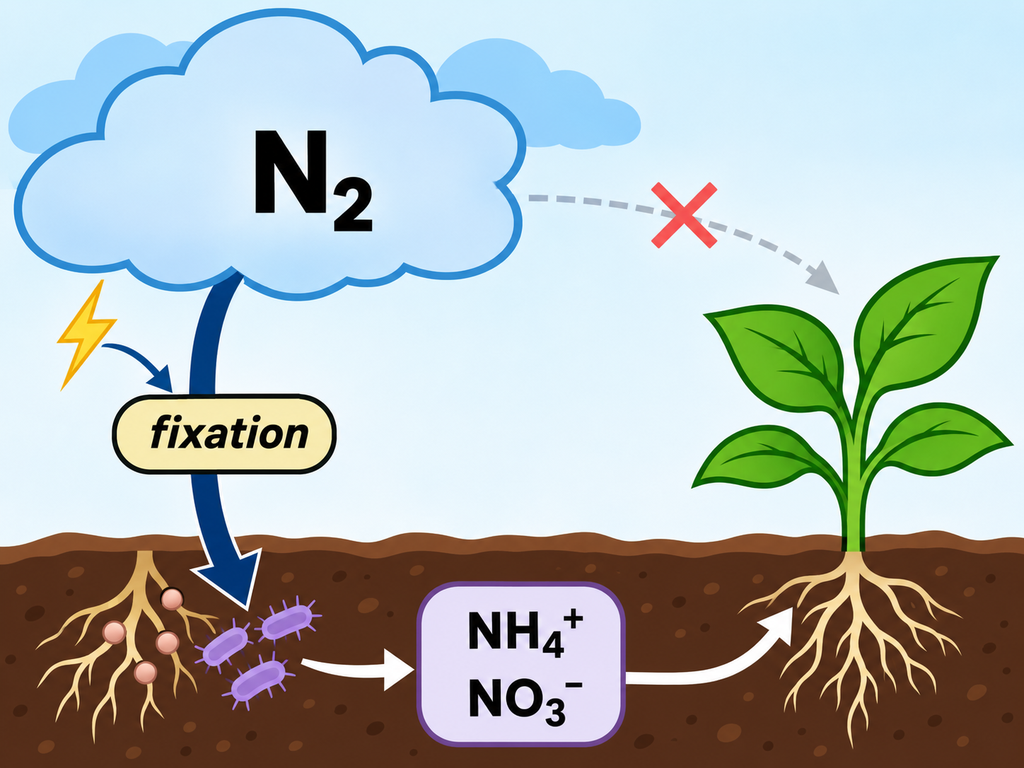

## Nitrogen changes form through microbial transformations

**Microbial transformations move nitrogen among atmospheric, inorganic, and organic pools, controlling its biological availability and return to the atmosphere**

- **Nitrogen fixation**
  - N<sub>2</sub> → NH<sub>3</sub> / NH<sub>4</sub><sup>+</sup>
- **Nitrification**
  - NH<sub>4</sub><sup>+</sup> → NO<sub>2</sub><sup>-</sup> → NO<sub>3</sub><sup>-</sup>
- **Assimilation**
  - inorganic N → organic biomass
- **Mineralization**
  - organic N → NH<sub>4</sub><sup>+</sup>
- **Denitrification**
  - NO<sub>3</sub><sup>-</sup> → N<sub>2</sub> / N<sub>2</sub>O

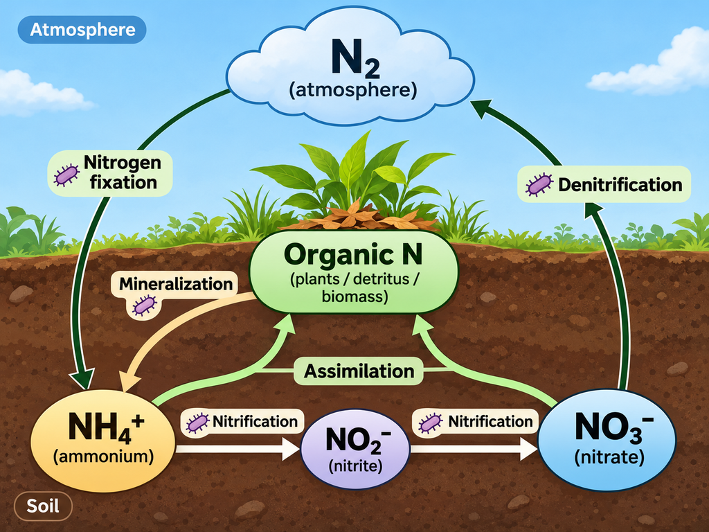

## Mineral nutrients cycle very differently

- **Nitrogen**
  - large atmospheric reservoir
  - strong microbial control
  - multiple gaseous pathways
  - can enter ecosystems through biological fixation
  - can be lost through denitrification and leaching
- **Phosphorus**
  - major reservoirs in rocks, soils and sediments
  - no major atmospheric gaseous reservoir
  - weathering is an important long-term input
  - strong binding to soils and minerals
  - loss through runoff, erosion and export
- **All essential mineral nutrients cycle through ecosystems.**
  - macronutrients (N, P, K, Ca, Mg, S) and micronutrients (Fe, Mn, Zn, Cu, etc.) move among organisms and environmental reservoirs.
  - each cycle can be described by where the nutrient is stored, how it becomes available, and how it is retained or lost.

## Decomposition drives internal nutrient recycling

- **Decomposition = breakdown of dead organic matter**
- **Mineralization = organic nutrients → inorganic forms**
- **Immobilization = microbes incorporate inorganic nutrients into microbial biomass**
- **Decomposition does not always mean nutrients become immediately available to plants**

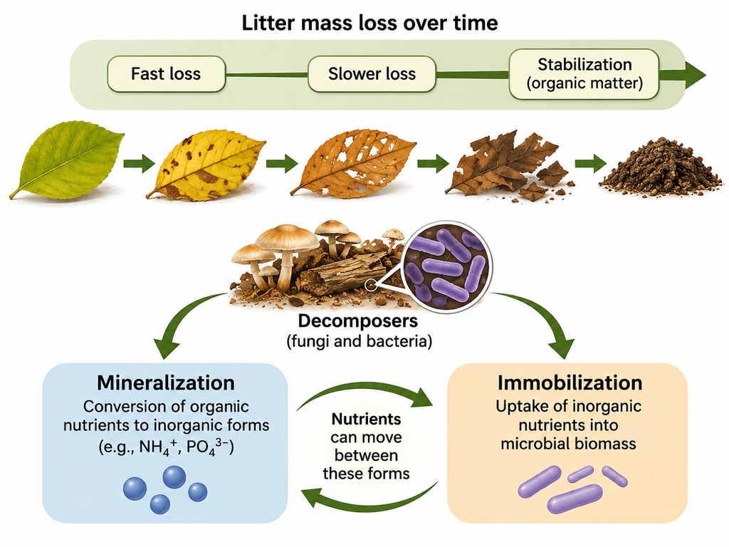

## What controls decomposition rate?

**Climate × substrate quality × decomposer community**

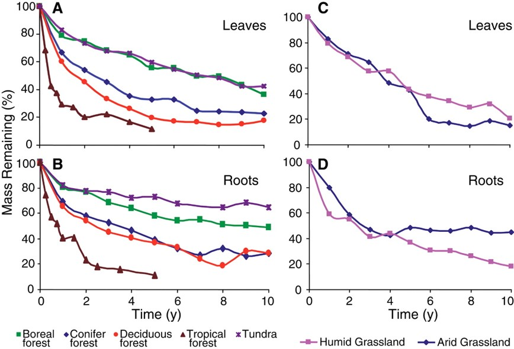

## Primary productivity is a flux — not a pool

- **Gross primary production (GPP)**
  - total carbon fixed by primary producers
- **Some fixed carbon is used in autotrophic respiration**
- **Net primary production (NPP)**
  - new producer biomass generated per unit time
- **Standing biomass is a pool**
- **NPP is a rate / flux**

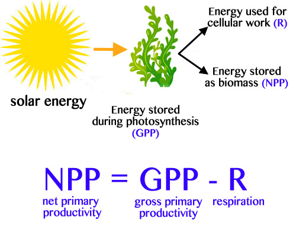

## Global NPP depends on both productivity and area

**High productivity per unit area does not necessarily mean large global contribution**

[figure not shown]

## Testable concepts

- **Matter cycling and ecosystem budgets**
  - pools, fluxes, transformations, residence time, inputs, outputs, and nutrient retention
- **Nutrient availability and limitation**
  - chemical form, N and P limitation, co-limitation, and ecological stoichiometry
- **Carbon and nitrogen cycling**
  - reservoirs, sources and sinks, microbial transformations, and human alteration of global cycles
- **Decomposition and primary productivity**
  - mineralization, controls on decomposition, GPP vs. NPP, and pool vs. flux